# Human Resource Data Analysis

zxxsummer

April 30, 2017

# 1. Introduction

Employee attrition is one of the biggest challenges that the company has to face. Human resourece department is looking forward to analysis and eventually executive recommendation based on data interpretation. **Problem Statement** is to explain the HR problem into three sub-questions which are also solved step by step. After clarifying the problem, data set continues to be presented and detected. **Data Exploration** is following the judgement that this data set is fit for the problem, and focuses on comparison and interpretation by the help of using data visualtion. To be specific, both detailed explanation of statistic graphs and shiny interactivity embeded into the graph are shown in this part.

# 2. Problem Statement

## 2.1 Problem

Employee attrition is one of the biggest challenges that the company has to face. There are many different reasons and possible factors for employees leaving. Retaining valued employees is the final purpose and needs targeted strategies. But are there reliables ways to figure out if and why the best and most experienced employees are leaving prematurely? Human resourece department is looking forward to analysis and eventually strategies or recommendation based on data interpretation. Following questions could be accomplished:

- Whether the data set offered by Human Resource Department is fit for the problem.(in “Data Overview” and “Data Processing” parts)
- The reasons why they left. Mainly compare those who left and those who did not leave to dectect possible reasons. (in “Data Analysis” part)
- How to interpretate the observation results so that executive recommendation could be achieved. (in “Observation and Interpretation” part)

## 2.2 Data Overview

In order to solve the above problem, a related data set is necessary. Here is a data set found on Kaggle (www.kaggle.com/ludobenistant/hr-analytics). After reading the data set into workplace, a quick overview is represeted as following.

```r
# Reading the csv data set called 'HR_comma_sep' and looking at the overall
# structure of data.
hr_data <- read.csv("HR_comma_sep.csv", header = T, sep = ",")
str(hr_data)
```

```
## 'data.frame':    14999 obs. of  10 variables:
##  $ satisfaction_level   : num  0.38 0.8 0.11 0.72 0.37 0.41 0.1 0.92 0.89 0.42 ...
##  $ last_evaluation      : num  0.53 0.86 0.88 0.87 0.52 0.5 0.77 0.85 1 0.53 ...
##  $ number_project       : int  2 5 7 5 2 2 6 5 5 2 ...
##  $ average_montly_hours : int  157 262 272 223 159 153 247 259 224 142 ...
##  $ time_spend_company   : int  3 6 4 5 3 3 4 5 5 3 ...
##  $ Work_accident        : int  0 0 0 0 0 0 0 0 0 0 ...
##  $ left                 : int  1 1 1 1 1 1 1 1 1 1 ...
##  $ promotion_last_5years: int  0 0 0 0 0 0 0 0 0 0 ...
##  $ department           : Factor w/ 10 levels "accounting","hr",..: 8 8 8 8 8 8 8 8 8 8 ...
##  $ salary               : Factor w/ 3 levels "high","low","medium": 2 3 3 2 2 2 2 2 2 2 ...
```

Understanding variables in detail comes to the first. There are 10 variables in this data set, as well as 14999 rows. Each row represents one sepcific employee in the company. Following is a table of variable’s name and its corresponding description.

The data set does highly relate to the problem to be solved, as it includes one variable of whether the employee has left, and various variables which can help to figure out the possible factors could cause the leaving, such like how employees satisfy the company (as the variable named “satisfaction_level”) as well as how the company evaluates their employees (as the variable named “last_evaluation”).

[output not shown]

# 3. Data Exploration

## 3.1 Data Processing

### Missing Value

At the beginging of exploring the data set, it is necessary to check whether missing values or other invalid values exist. If so, it comes to complete missing values with proper strategies and methods. If not, continuing following analysis. The number of missing value in the data set is actually 0. Now, a completed data set is ready for following analysis.

### Correlation

Calculating the correlations between all different combinations of data allows us to get first hints on why people leave. However, correlation requires that the type of variable is numeric so that changing the class of variables from factor to numeric.

```r
# Taking a look at the class of all variables
sapply(hr_data, class)
```

```
##    satisfaction_level       last_evaluation        number_project
##             "numeric"             "numeric"             "integer"
##  average_montly_hours    time_spend_company         Work_accident
##             "integer"             "integer"             "integer"
##                  left promotion_last_5years            department
##             "integer"             "integer"              "factor"
##                salary
##              "factor"
```

Here we can see that “department” and “salary” are factor.

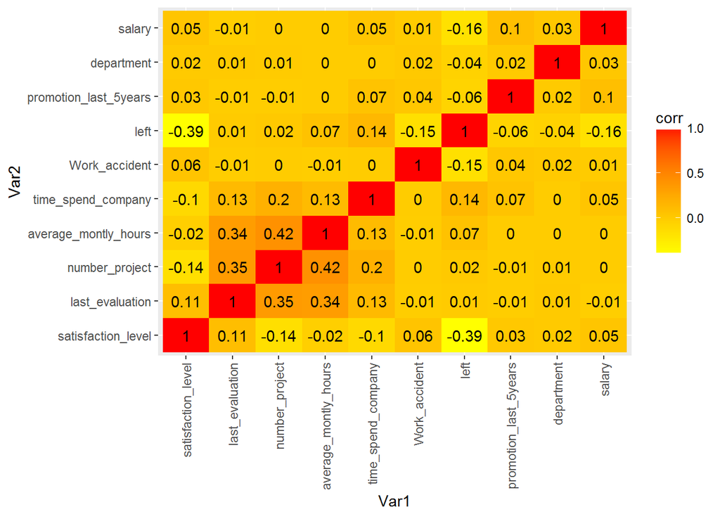

```r
# Changing to numeric type
hrdata <- hr_data
hrdata$department <- as.numeric(1:10)[match(hrdata$department, unique(hrdata$department))]
hrdata$salary <- as.numeric(1:3)[match(hrdata$salary, c("low", "medium", "high"))]
# Caculating correlation between each pair of varialbes
corr <- melt(cor(hrdata))
names(corr) <- c("Var1", "Var2", "corr")
# Making correlation visualized graph
ggplot(corr, aes(Var1, Var2, fill = corr)) + geom_tile() + scale_fill_gradient(low = "yellow",
    high = "red") + geom_text(aes(label = round(corr, 2))) + theme(axis.text.x = element_text(angle = 90,
    hjust = 1, vjust = 0.5))
```

The “left” is the dependent variable for the problem since it is going to figure our the reasons why employees left. As we can see from the correlation graph, the top four factors that are relatively high correlated with “left” are “satisfication level”, “salary”, “work accident”, and “time spend at company”. To be specific, the most correlated factor is the level how employees statify the company. The higher satisfaction level, the less possbility to leave. Furthermore analysis on the variable could interpretate deeper.

## 3.2 Data Analysis

Although people who left the company have their own reasons as an individual, comparing those who left and those who did not leave would give more perspectives. So divide the entire into two groups and comparing them of each variable. There are three continuous variables: “satisfaction level”,“last evaluation”,“average monthly hours”. Meanwhile, others could be treated as categorical variables. Different plots would be selected to figure out their own trend for above two types of variables, repectively, density and histogram. Eventually each plot will use different color to represent whether employees left or not.

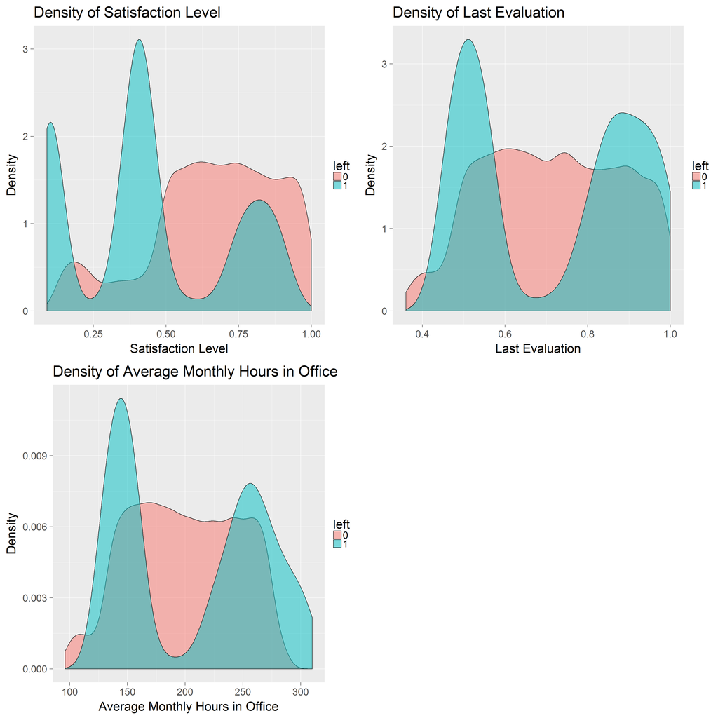

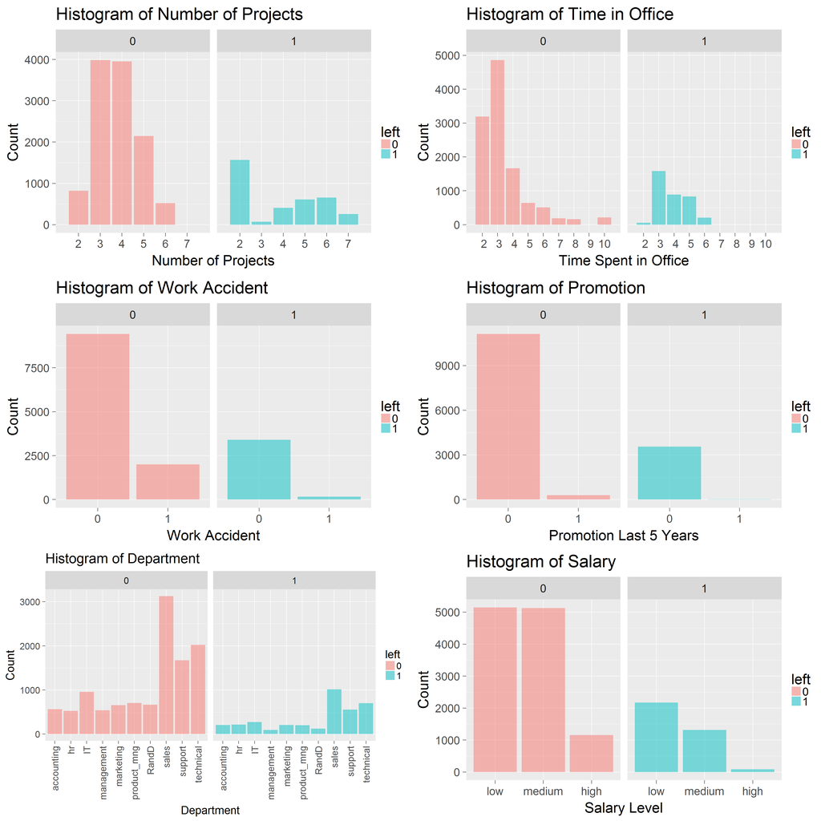

### Obersavertion and Interpretation

- **Satisfaction Level and Last Evaluation**

The mean satisfaction level of those who have left is apparently lower than those who did not. As for people who left, there are three peaks of satisfaction level instead of two. Is there any possible classification of these group? Going back to check the correlation graph, other two variables are highly correlated with satisfaction level. They are “last evaluation” and “number of projects”. Now, turn to analyze the relationship between them.

```r
# The relationship between satisfaction level and last evaluation Using
# shiny interactivity with ggvis, the size of the points as well as the
# opacity could be changed.  So that much more clear pattern could be shown
# which could be deeper interpretation.
hr_data %>% ggvis(~satisfaction_level, ~last_evaluation, stroke = ~left, `:=`(fill,
    "white"), `:=`(size, input_slider(10, 100, label = "size")), `:=`(opacity,
    input_slider(0, 1, label = "Opacity"))) %>% layer_points() %>% add_axis("x",
    orient = "bottom", title = "Satisfaction Level") %>% add_axis("y", title = "Last Evaluation")
```

[output not shown]

**1. Best Match:** people who possesses both high satisfaction and high evaluation. They are content with the company, and the company is also content with them. They seem to be the best match with the company, but they decide to leave. The reason behind this group might be more individual rather than caused by the company.

**2. Over Qualified:** people who possesses low satisfaction but high evaluation. They are too excellent to be content by the company. They decide to leave probably because they are pursuing better platform instead of standing at the same point.

**3. Worst Match:** people who possesses both low satisfaction and low evaluation. They are the opposite side of the best match. Their bad performance might also leads to their leaving, In other words, they might be fired by the company.

- **Average Monthly Hours and Number of Projects**

For employees who left, there are two peaks in the density of average monthly hours. That means they are much more probably to leave if they spend too much or too little time in office. Meanwhile, employees who left have either too many or too few projects. Actually, to some degree, the number of projects you are assigned lead to the amount of time you spend in office.

- **Work Accident and Promotion**

Comparing with employees who left or not, similar results are shown on these two variables. In terms of the percentage of having work accident, employees who left are lower than those who did not, as the same as the percentage of being promoted.

# 4. Conclusion

As above, in order to figure out the reasons why employees left and the main factors, we first focus on comparing people by different variables and obtain the obersations. During the comparison, we find that some other variables could be used to explain the most related factor to left (that is “satisfaction_level”).Then we continue to divide those who left into three subgroups and try to explain seperately.